# DGA Deep Learning

```r
library(tidyverse)
library(dbplyr)
library(RMySQL)
library(stringr)
library(keras)
library(reshape2)
library(abind)
library(caret)
library(plotROC)
library(plotly)
```

# Database Generation

| domain | label | date | id |
| --- | --- | --- | --- |
| akamaiedge.net | normal |  | 4419632 |
| adadvisor.net | normal |  | 4419636 |
| chartbeat.net | normal |  | 4419647 |
| acxiom-online.com | normal |  | 4419658 |
| imrworldwide.com | normal |  | 4419659 |
| adsymptotic.com | normal |  | 4419686 |
| symcd.com | normal |  | 4419687 |
| symantecliveupdate.com | normal |  | 4419694 |
| addthisedge.com | normal |  | 4419703 |
| burstnet.com | normal |  | 4419709 |

[output cut: 990 more lines]

## Dataset Class Distribution

| dga | legit |
| --- | --- |
| 1366504 | 1003161 |

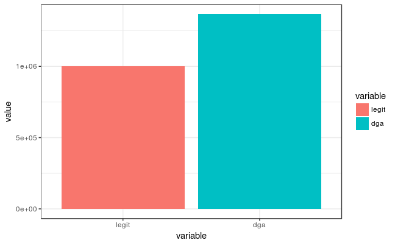

```r
ggplot(melt(labels_freq ))+
  geom_col(aes(x=variable,y=value,fill=variable))+
  theme_bw()
```

## Malware families Episode Frequency Distribution

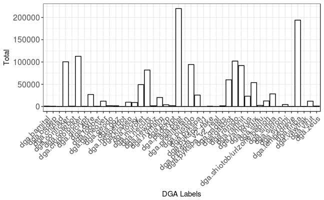

## Top 5 DGA families

| label | freq |
| --- | --- |
| dga.post | 220000 |
| dga.tinba | 193912 |
| dga.cryptolocker | 112809 |
| dga.ramdo | 102000 |
| dga.conficker | 100496 |

```r
class_dga=domains_tbl %>% filter(grepl("dga",label)) %>% filter(!(label %in% blacklisted_labels))
# calculate Char freq by DGA type
charlist_by_type=class_dga  %>% group_by(label) %>% do(charlist= unlist(sapply(.$domain, function(x) c(str_split(x,"")[1]))))
```

```
|=============================================================================================================|100% ~0 s remaining
```

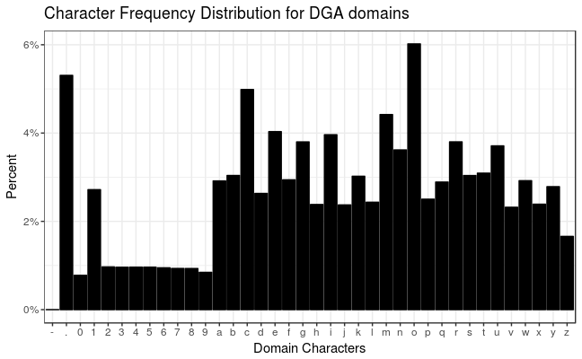

```r
dga_type=as.vector(unlist(charlist_by_type$charlist))
charlist_dga_plot<-ggplot(data.frame(charlist=dga_type),aes(x=charlist))+
   geom_bar(col="black",fill='black',aes(y = (..count..)/sum(..count..)))+
  scale_y_continuous(labels=percent)+ylab("Percent")+xlab("Domain Characters")+
  ggtitle("Character Frequency Distribution for DGA domains")+
  theme_bw()
ggsave(plot=charlist_dga_plot,filename = "/home/harpo/Dropbox/ongoing-work/publicaciones/argencon2018-DGANN/dga_charlist_freq.eps",device = "eps", width =8, height = 2)
charlist_dga_plot
```

```r
charlist_normal_plot<-ggplot(data.frame(charlist=normal) %>% filter(),aes(x=charlist))+
   geom_bar(col="black",fill='white',aes(y = (..count..)/sum(..count..)))+
  scale_y_continuous(labels=percent)+ylab("Percent")+xlab("Domain Characters")+
  ggtitle("Character Frequency Distribution for Normal domains")+
  theme_bw()
```

```
Error in data.frame(charlist = normal) : objeto 'normal' no encontrado
```

# Dataset preprocessing

## Base functions

```r
set.seed(12121)
train_test_sample<-function(x,percent=0.7){
  smp_size <- floor(percent * nrow(x))
  train_ind <- sample(seq_len(nrow(x)), size = smp_size)
  return (train_ind)
}
train_normal=c()
valid_normal=c()
test_normal=c()
train_dga=c()
valid_dga=c()
test_dga=c()
for (i in 1:length(labels)){
  d<-domains_tbl %>% filter(label==labels[i]) #%>% head(10000)
  d$domain1<-str_split(d$domain,"\\.",simplify = T)[,1]
  # TODO: Reemplazar por sample()
  dindex<-train_test_sample(d,0.4)
  train<-d[dindex,]
  test<-d[-dindex,]
  tindex<-train_test_sample(test,0.5)
  valid<-test[tindex,]
  test<-test[-tindex,]
  if(str_detect(labels[i],"normal")){
    train_normal<-rbind(train_normal,cbind(domain=train$domain1,label=train$label))
    valid_normal<-rbind(valid_normal,cbind(domain=valid$domain1,label=valid$label))
    test_normal<-rbind(test_normal,cbind(domain=test$domain1,label=test$label))
  }else{
    train_dga<-rbind(train_dga,cbind(domain=train$domain1,label=train$label))
    valid_dga<-rbind(valid_dga,cbind(domain=valid$domain1,label=valid$label))
    test_dga<-rbind(test_dga,cbind(domain=test$domain1,label=test$label))
  }
}
```

```r
library(keras)
valid_characters <- "$abcdefghijklmnopqrstuvwxyz0123456789-_."
valid_characters_vector <- strsplit(valid_characters,split="")[[1]]
tokens <- 0:length(valid_characters_vector)
names(tokens) <- valid_characters_vector
#
# Aux functions
#
# convert dataset to matrix of tokens
tokenize <- function(data,labels){
  #string_char_vector <- strsplit(string,split="")[[1]]
   x_data <- sapply(
     lapply(data,function(x) strsplit(tolower(x),split="")),function(x) lapply(x[[1]], function(x) tokens[[x]]))
     padded_token<-pad_sequences(x_data,maxlen=45,padding='post', truncating='post')
  return (list(encode=padded_token,domain=data, label=labels))
  #return (list(encode=padded_token))
}
# convert vector with char tokens to one-hot encodings
to_onehot <- function(data,shape){
  train <- array(0,dim=c(shape[1],shape[2],shape[3]))
  for (i in 1:shape[1]){
    for (j in 1:shape[2])
      train[i,j,data[i,j]] <- 1
  }
  return (train)
}
# Create a dataset
build_dataset<- function(data,maxlen){
  dataset<-tokenize(data[,1],data[,2])
  shape=c(nrow(dataset$encode),maxlen,length(valid_characters_vector))
  #dataset$encode<-to_onehot(dataset$encode,shape)
  return(dataset)
}
```

# The actual dataset creation

```r
maxlen=45
train_normal_dataset<-build_dataset(train_normal,maxlen)
valid_normal_dataset<-build_dataset(valid_normal,maxlen)
test_normal_dataset<-build_dataset(test_normal,maxlen)
train_dga_dataset<-build_dataset(train_dga,maxlen)
valid_dga_dataset<-build_dataset(valid_dga,maxlen)
test_dga_dataset<-build_dataset(test_dga,maxlen)
#save(train_normal_dataset,file="/home/harpo/Dropbox/ongoing-work/git-repos/dga-algos/data/train_normal_dataset.rda")
#save(valid_normal_dataset,file="/home/harpo/Dropbox/ongoing-work/git-repos/dga-algos/data/valid_normal_dataset.rda")
#save(test_normal_dataset,file="/home/harpo/Dropbox/ongoing-work/git-repos/dga-algos/data/test_normal_dataset.rda")
#save(train_dga_dataset,file="/home/harpo/Dropbox/ongoing-work/git-repos/dga-algos/data/train_dga_dataset.rda")
#save(valid_dga_dataset,file="/home/harpo/Dropbox/ongoing-work/git-repos/dga-algos/data/valid_dga_dataset.rda")
#save(test_dga_dataset,file="/home/harpo/Dropbox/ongoing-work/git-repos/dga-algos/data/test_dga_dataset.rda")
```

## Save dataset objects

```r
save(train_normal_dataset,file="/home/harpo/Dropbox/ongoing-work/git-repos/dga-algos/data/train_normal_dataset.rda")
save(valid_normal_dataset,file="/home/harpo/Dropbox/ongoing-work/git-repos/dga-algos/data/valid_normal_dataset.rda")
save(test_normal_dataset,file="/home/harpo/Dropbox/ongoing-work/git-repos/dga-algos/data/test_normal_dataset.rda")

save(train_dga_dataset,file="/home/harpo/Dropbox/ongoing-work/git-repos/dga-algos/data/train_dga_dataset.rda")
save(valid_dga_dataset,file="/home/harpo/Dropbox/ongoing-work/git-repos/dga-algos/data/valid_dga_dataset.rda")
save(test_dga_dataset,file="/home/harpo/Dropbox/ongoing-work/git-repos/dga-algos/data/test_dga_dataset.rda")
```

## Keras Dataset Narray reshape

```r
train_dataset_x<-abind(train_dga_dataset$encode,train_normal_dataset$encode,along=1)
train_dataset_y<-c(rep(1,nrow(train_dga_dataset$encode)),rep(0,nrow(train_normal_dataset$encode)))

valid_dataset_x<-abind(valid_dga_dataset$encode,valid_normal_dataset$encode,along=1)
valid_dataset_y<-c(rep(1,nrow(valid_dga_dataset$encode)),rep(0,nrow(valid_normal_dataset$encode)))

test_dataset_x<-abind(test_dga_dataset$encode,test_normal_dataset$encode,along=1)
test_dataset_y<-c(rep(1,nrow(test_dga_dataset$encode)),rep(0,nrow(test_normal_dataset$encode)))
```

## Keras input layer

```r
input_shape <- dim(train_dataset_x)[2]
inputs<-layer_input(shape = input_shape)
```

### On embedding

As far as I know, the Embedding layer is a simple matrix multiplication that transforms words into their corresponding word embeddings.

The weights of the Embedding layer are of the shape (vocabulary_size, embedding_dimension). For each training sample, its input are integers, which represent certain words. The integers are in the range of the vocabulary size. The Embedding layer transforms each integer i into the ith line of the embedding weights matrix.

In order to quickly do this as a matrix multiplication, the input integers are not stored as a list of integers but as a one-hot matrix. Therefore the input shape is (nb_words, vocabulary_size) with one non-zero value per line. If you multiply this by the embedding weights, you get the output in the shape

(nb_words, vocab_size) x (vocab_size, embedding_dim) = (nb_words, embedding_dim) So with a simple matrix multiplication you transform all the words in a sample into the corresponding word embeddings

### On layer_conv_1d

*filters:* Integer, the dimensionality of the output space (i.e. the number output of filters in the convolution). Un filtro se corresponde a una neurona y cuyo peso determinan el kernel utilizado para la convolucion. Cada neurona tendra una convolucion diferente con un kernel distinto(el kernel es el mismo??), aunque del mismo tamaño.

*kernel_size:* An integer or list of a single integer, specifying the length of the 1D convolution window.

*strides:* An integer or list of a single integer, specifying the stride length of the convolution. Specifying any stride value != 1 is incompatible with specifying any dilation_rate value != 1.

## Keras model creation and training

```r
nb_filter <- 256
kernel_size <- 4
embedingdim <- 100
embeding<- inputs %>% layer_embedding(length(valid_characters_vector), embedingdim , input_length = input_shape)
conv1d <- embeding %>%
  layer_conv_1d(filters = nb_filter, kernel_size = kernel_size, activation = 'relu', padding='valid',strides=1) %>%
  layer_flatten() %>%
  layer_dense(1024,activation='relu') %>%
  layer_dense(1,activation = 'sigmoid')
#compile model
model <- keras_model(inputs = inputs, outputs = conv1d)
model %>% compile(
  optimizer = 'adam',
  loss = 'binary_crossentropy',
  metrics = c('accuracy')
)
summary(model)
```

```
_________________________________________________________________________________________________________________________________________________________________________________
Layer (type)                                                                   Output Shape                                                           Param #
=================================================================================================================================================================================
input_1 (InputLayer)                                                           (None, 45)                                                             0
_________________________________________________________________________________________________________________________________________________________________________________
embedding_1 (Embedding)                                                        (None, 45, 100)                                                        4000
_________________________________________________________________________________________________________________________________________________________________________________
conv1d_1 (Conv1D)                                                              (None, 42, 256)                                                        102656
_________________________________________________________________________________________________________________________________________________________________________________
flatten_1 (Flatten)                                                            (None, 10752)                                                          0
_________________________________________________________________________________________________________________________________________________________________________________
dense_1 (Dense)                                                                (None, 1024)                                                           11011072
_________________________________________________________________________________________________________________________________________________________________________________
dense_2 (Dense)                                                                (None, 1)                                                              1025
=================================================================================================================================================================================
Total params: 11,118,753
Trainable params: 11,118,753
Non-trainable params: 0
_________________________________________________________________________________________________________________________________________________________________________________
```

```r
tensorboard("logs/run_a")
```

```
TensorBoard 0.1.8 at http://127.0.0.1:6224 (Press CTRL+C to quit)
```

```
Started TensorBoard at http://127.0.0.1:6224
```

```r
callbacks = list(
  callback_tensorboard(
    log_dir = "logs/run_a",
    histogram_freq = 1,
    embeddings_freq = 1,
    write_graph = FALSE
  )
)
history_5epochs<-model %>% fit(train_dataset_x,train_dataset_y,epochs = 5, batch_size = 4096, validation_data = list(valid_dataset_x,valid_dataset_y))
```

```
Train on 947854 samples, validate on 710898 samples
```

[output not shown]

```r
#model %>% save_model_hdf5("cnn-nomlp.h5")
```

## Keras model learning rate

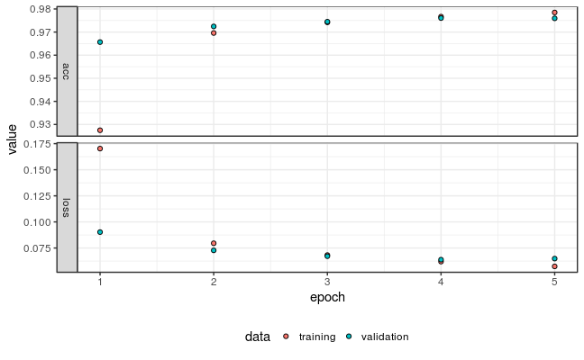

```r
history_plot<-plot (history_5epochs)+
  #geom_line()+
  theme_bw()+
  theme(legend.position="bottom")
#ggsave(plot=history_plot,filename = "/home/harpo/Dropbox/ongoing-work/publicaciones/argencon2018-DGANN/nn_epoch.eps",device = "eps", width =8, height = 3)
history_plot
```

## Keras model results on testset

```r
preds<-ifelse(predsprobs>0.9,1,0)
confusionMatrix(preds,test_dataset_y,positive = '1')
```

```
Confusion Matrix and Statistics

          Reference
Prediction      0      1
         0 298405  18179
         1   2544 391785

               Accuracy : 0.9709
                 95% CI : (0.9705, 0.9712)
    No Information Rate : 0.5767
    P-Value [Acc > NIR] : < 2.2e-16

                  Kappa : 0.9407
 Mcnemar's Test P-Value : < 2.2e-16

            Sensitivity : 0.9557
            Specificity : 0.9915
         Pos Pred Value : 0.9935
         Neg Pred Value : 0.9426
             Prevalence : 0.5767
         Detection Rate : 0.5511
   Detection Prevalence : 0.5547
      Balanced Accuracy : 0.9736

       'Positive' Class : 1
```

## Keras Model AUC

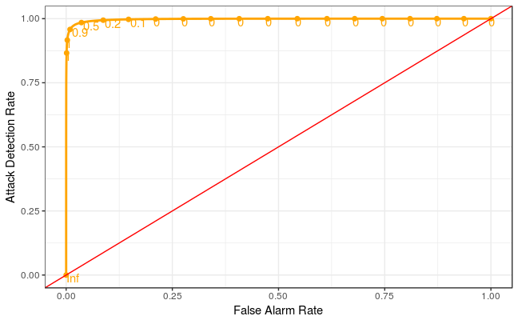

# Keras model results

## Keras model results per DGA family

```r
nntest<-data.frame(predicted_probability=predsprobs,class=test_dataset_y,label= c(test_dga_dataset$label,test_normal_dataset$label),domain=c(test_dga_dataset$domain,test_normal_dataset$domain))

nntest<-nntest %>% mutate(predicted_class=ifelse(predicted_probability>0.9,1,0))
nntest<-nntest %>% mutate(label=str_replace(label,"conflicker","conficker"))
recall<-nntest %>% group_by(label) %>% summarise(recall=sum(predicted_class==class)/n(),support=n())
recall_dga<-recall %>% filter(!grepl('normal',label)) %>% mutate(label=str_replace(label,"conflicker","conficker"))
recall_normal<-recall %>% filter(grepl('normal',label)) %>% mutate(label=str_replace(label,"conflicker","conficker"))

#precision_far=nntest %>% group_by(label) %>% summarise(precision=1-(sum(predicted_class!=class)/n()),support=n())
#recall=recall %>% filter( label %in% worbased)
#confusionMatrix(nntest$predicted_class,nntest$class)

whaleboneplot<-ggplot(recall_dga %>% filter(!grepl('normal',label)) %>% mutate(label=str_replace(label,"conflicker","conficker")),aes(x=label,y=recall))+
  geom_point(aes(size=support),color='black',fill='orange',shape = 21,alpha=0.5)+
  geom_point(size=1,color='blue',fill='blue',shape = 21)+
  ylab("Attack Detection Rate")+
  ggtitle("")+
  theme_bw()+
  theme(axis.text.x = element_text(angle = 45, hjust = 1))+
  scale_color_gradient2(low = "cyan", mid='blue',high = "red")+
   xlab('DGA Malware families' )+
   guides(colour=FALSE,size=FALSE)+
    scale_size_continuous(range = c(5,15))
 # scale_size_area(max_size = 15)
ggsave(plot=whaleboneplot,filename = "/home/harpo/Dropbox/ongoing-work/publicaciones/argencon2018-DGANN/recall_per_malware_2.png",device = "png", width =8, height = 4)

whaleboneplot
```

[output not shown]

## Keras model results per normal type

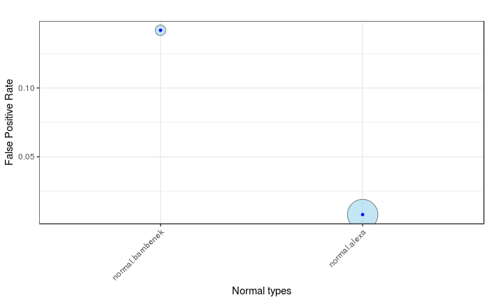

## ADR vs frequency per DGA family

```r
recall  %>%  arrange((recall))

freq_adr_fig<-ggplot(recall,aes(x=recall,y=support))+
  geom_point(color='blue',aes(text=label),alpha=0.6)+
  xlab("Attack Detection Rate")+ylab("Frequency")+
  geom_smooth(method='lm',color='orange')+

  geom_point(x=0.7858304,y=30149,color='red')+
  geom_text(x=0.7858304,y=34049,label='conficker')+

  geom_point(x=0.6389513,y=1335,color='red')+
  geom_text(x=0.6389513,y=-1335,label='symmi')+

  geom_point(x=0.4976382,y=3599,color='red')+
  geom_text(x=0.4976382,y=6599, label='virut')+

  geom_point(x=0.9915788,y=33843,color='green')+
  geom_text(x=0.9915788,y=36843, label='cryptolocker')+

  geom_point(x=0.9984641,y=30600,color='green')+
  geom_text(x=0.9984641,y=27600, label='ramdo')+

  geom_point(x=0.9999697,y=66000,color='green')+
  geom_text(x=0.9999697,y=64000, label='post')+

  geom_point(x=0.9953588,y=58174,color='green')+
  geom_text(x=0.9953588,y=55174, label='tinba')+

  theme_bw()
freq_adr_fig
ggplotly()
recall %>% inner_join(top_dga_families,by='label')

ggsave(plot=freq_adr_fig,filename = "/home/harpo/Dropbox/ongoing-work/publicaciones/argencon2018-DGANN/dga_freq_adr_fig.png",device = "png", width =10, height = 4)
```

```r
nntest

FN_domains<-nntest %>% filter(predicted_class == 0 & class == 1) %>% select(domain,predicted_probability,label)
FP_domains<-nntest %>% filter(predicted_class == 1 & class == 0) %>% select(domain,predicted_probability,label)
TP_domains<-nntest %>% filter(predicted_class == 1 & class == 1) %>% select(domain,predicted_probability,label)
TN_domains<-nntest %>% filter(predicted_class == 0 & class == 0) %>% select(domain,predicted_probability,label)
```

## Character Frequency distribution of results (FN,FP,TN,TP)

```r
char_dist<- function(label_name){
  library(scales)

  charlist_FN=FN_domains %>% filter(grepl(label_name,label)) %>% group_by(label) %>% do(charlist= unlist(sapply(.$domain, function(x) c(str_split(x,"")[1]))))
  charlist_TP=TP_domains %>% filter(grepl(label_name,label)) %>%group_by(label) %>% do(charlist= unlist(sapply(.$domain, function(x) c(str_split(x,"")[1]))))

  charlist_FN=as.vector(unlist(charlist_FN %>% select(charlist)))
  charlist_TP=as.vector(unlist(charlist_TP %>% select(charlist)))

  tpplot<-ggplot(data.frame(charlist=charlist_TP),aes(x=charlist))+
    geom_bar(col="black",fill='white',aes(y = (..count..)/sum(..count..)))+
    scale_y_continuous(labels=percent)+ylab("Percent")+xlab("")+
    theme_bw()


  fnplot<-ggplot(data.frame(charlist=charlist_FN),aes(x=charlist))+
    geom_bar(col="black",fill='black',aes(y = (..count..)/sum(..count..)))+
    scale_y_continuous(labels=percent)+ylab("Percent")+xlab("")+
    theme_bw()

  #gridExtra::grid.arrange(fnplot,tpplot,ncol=1)
  return(list(fnplot=fnplot,tpplot=tpplot))
}

conf_charlist<-char_dist("dga.conficker")
symmi_charlist<-char_dist("dga.symmi")
virut_charlist<-char_dist("dga.virut")

gridExtra::grid.arrange(
conf_charlist$fnplot+ggtitle("Conficker False Negative Character Distribution"),
symmi_charlist$fnplot+ggtitle("Symmi False Negative Character Distribution"),
virut_charlist$fnplot+ggtitle("Virut False Negative Character Distribution"),
ncol=1)

ggsave(plot=conf_charlist$fnplot+ggtitle("Conficker False Negative Character Frequency Distribution"),
       filename = "/home/harpo/Dropbox/ongoing-work/publicaciones/argencon2018-DGANN/conficker_charlist_freq.eps",device = "eps", width =8, height = 2)

ggsave(plot=symmi_charlist$fnplot+ggtitle("Symmi False Negative Character Frequency Distribution"),
       filename = "/home/harpo/Dropbox/ongoing-work/publicaciones/argencon2018-DGANN/symmir_charlist_freq.eps",device = "eps", width =8, height = 2)

ggsave(plot=virut_charlist$fnplot+ggtitle("Virut False Negative Character Frequency Distribution"),
       filename = "/home/harpo/Dropbox/ongoing-work/publicaciones/argencon2018-DGANN/virut_charlist_freq.eps",device = "eps", width =8, height = 2)
```

## PCA projection of results (FN, FP, TN, TP)

```r
pca_projection<-function(label_name){
  FN_tokenized=tokenize(as.matrix(FN_domains  %>% filter(grepl(label_name,label)) %>% select(domain)),FN_domains$label)
  TP_tokenized=tokenize(as.matrix(TP_domains  %>% filter(grepl(label_name,label)) %>% select(domain)),TP_domains$label)
  FN_tokenized$label<-rep("FN", length(FN_tokenized$domain))
  TP_tokenized$label<-rep("TP", length(TP_tokenized$domain))

  malware_results=list()
  malware_results$encode<-abind(FN_tokenized$encode,TP_tokenized$encode,along=1)
  malware_results$domain<-c(FN_tokenized$domain,TP_tokenized$domain)
  malware_results$label<-c(FN_tokenized$label,TP_tokenized$label)

  nrow(malware_results$encode)
  length(malware_results$label)
  length(malware_results$domain)

  pca=prcomp(malware_results$encode[,1:11],center=TRUE,scale.=TRUE)
  pca_data<-data.frame(pca$x,label=malware_results$label,domain=malware_results$domain)
  pca_plot<-ggplot(pca_data %>% sample_n(1000),aes(x=PC1,y=PC4))+
    geom_point(aes(color=label,text=domain),alpha=0.5)+
    theme_bw()

  return (list(pca_plot=pca_plot,pca_data=pca_data))
}
r<-pca_projection("dga.conficker")
r<-pca_projection("dga.symmi")
r<-pca_projection("dga.virut")

r$pca_plot

ggsave(plot=r$pca_plot+ theme(legend.position="bottom"),
       filename = "/home/harpo/Dropbox/ongoing-work/publicaciones/argencon2018-DGANN/conficker_fn_pca.pdf",device = "pdf", width =8, height = 3)
#ggplotly()
#plot_ly(r$pca_data %>% sample_n(1000), type="scatter3d", x = ~PC1, y = ~PC2, z = ~PC3, color = ~label, colors = c('#BF382A', '#0C4B8E'), opacity=0.5, marker = list(size = 3),text = ~domain) %>% layout(title = "Detection Results using Convnet 1D")
```

## Character len distribution

```r
len_freq<-ggplot(r$pca_data  %>% mutate(len=str_length(domain)))+
  geom_histogram(aes(x=len,fill=label),bins=15)+ylab("Frequency Episode")+xlab("length")+
  theme_bw()

ggsave(plot=len_freq+ theme(legend.position="bottom"),
       filename = "/home/harpo/Dropbox/ongoing-work/publicaciones/argencon2018-DGANN/conficker_len.pdf",device = "pdf", width =8, height = 3)
len_freq
```

```r
charlist_FN=FN_domains %>% group_by(label) %>% do(charlist= unlist(sapply(.$domain, function(x) c(str_split(x,"")[1]))))
charlist_FP=FP_domains %>% group_by(label) %>% do(charlist= unlist(sapply(.$domain, function(x) c(str_split(x,"")[1]))))
charlist_TP=TP_domains %>% group_by(label) %>% do(charlist= unlist(sapply(.$domain, function(x) c(str_split(x,"")[1]))))
charlist_TN=TN_domains %>% group_by(label) %>% do(charlist= unlist(sapply(.$domain, function(x) c(str_split(x,"")[1]))))

charlist_FN=as.vector(unlist(charlist_FN %>% select(charlist)))
charlist_FP=as.vector(unlist(charlist_FP %>% select(charlist)))
charlist_TP=as.vector(unlist(charlist_TP %>% select(charlist)))
charlist_TN=as.vector(unlist(charlist_TN %>% select(charlist)))

save(charlist_FN,file  ="/home/harpo/Dropbox/ongoing-work/git-repos/dga-wb-r/charlist_FN.rda")
save(charlist_FP,file  ="/home/harpo/Dropbox/ongoing-work/git-repos/dga-wb-r/charlist_FP.rda")
save(charlist_TP,file  ="/home/harpo/Dropbox/ongoing-work/git-repos/dga-wb-r/charlist_TP.rda")
save(charlist_TN,file  ="/home/harpo/Dropbox/ongoing-work/git-repos/dga-wb-r/charlist_TN.rda")
```

```r
library(scales)
tpplot<-ggplot(data.frame(charlist=charlist_TP),aes(x=charlist))+
    geom_bar(col="black",fill='white',aes(y = (..count..)/sum(..count..)))+
    scale_y_continuous(labels=percent)+ylab("Percent")+xlab("")+
   theme_bw()

tnplot<-ggplot(data.frame(charlist=charlist_TN),aes(x=charlist))+
    geom_bar(col="black",fill='white',aes(y = (..count..)/sum(..count..)))+
    scale_y_continuous(labels=percent)+ylab("Percent")+xlab("")+
   theme_bw()



fnplot<-ggplot(data.frame(charlist=charlist_FN),aes(x=charlist))+
    geom_bar(col="black",fill='white',aes(y = (..count..)/sum(..count..)))+
    scale_y_continuous(labels=percent)+ylab("Percent")+xlab("")+
   theme_bw()

fpplot<-ggplot(data.frame(charlist=charlist_FP),aes(x=charlist))+
    geom_bar(col="black",fill='white',aes(y = (..count..)/sum(..count..)))+
    scale_y_continuous(labels=percent)+ylab("Percent")+xlab("")+
   theme_bw()
gridExtra::grid.arrange(fnplot,tpplot,fpplot,tnplot,ncol=1)
```

```r
input_shape <- dim(train_dataset_x)[2]
inputs<-layer_input(shape = input_shape)

embeding<- inputs %>% layer_embedding(length(valid_characters_vector), 128 , input_length = input_shape)

lstm <- embeding %>%
  layer_lstm(units = 128) %>%
  layer_dropout(rate = 0.5) %>%
  layer_dense(1, activation = 'sigmoid')

#compile model
model_endgame <- keras_model(inputs = inputs, outputs = lstm)
model_endgame %>% compile(
  optimizer = 'rmsprop',
  loss = 'binary_crossentropy',
  metrics = c('accuracy')
)
summary(model_endgame)
model_endgame %>% fit(train_dataset_x,train_dataset_y,epochs = 10, batch_size = 4096, validation_data = list(valid_dataset_x,valid_dataset_y))
```

```r
predsprobs_endgame<-model_endgame %>% predict(test_dataset_x, batch_size=4096)
preds_endgame<-ifelse(predsprobs_endgame>0.9,1,0)
confusionMatrix(preds_endgame,test_dataset_y,positive = '1')
```

```r
nntest_endgame<-data.frame(predicted_probability=predsprobs_endgame,class=test_dataset_y,label= c(test_dga_dataset$label,test_normal_dataset$label),domain=c(test_dga_dataset$domain,test_normal_dataset$domain))

nntest_endgame<-nntest_endgame %>% mutate(predicted_class=ifelse(predicted_probability>0.9,1,0))

recall_endgame<-nntest_endgame %>% group_by(label) %>% summarise(recall=sum(predicted_class==class)/n(),support=n())

plot_endgame<-ggplot(recall_endgame %>% filter(!grepl('normal',label)) ,aes(x=label,y=recall))+
  geom_point(aes(size=support),color='black',fill='skyblue',shape = 21,alpha=0.5)+
  geom_point(size=1,color='blue',fill='blue',shape = 21)+
  ggtitle("NN ")+
  theme_bw()+
  theme(axis.text.x = element_text(angle = 45, hjust = 1))+
  scale_color_gradient2(low = "cyan", mid='blue',high = "red")+
   xlab('Types' )+ylab("Recall")+
   guides(colour=FALSE,size=FALSE)+
    scale_size_continuous(range = c(5,15))
 # scale_size_area(max_size = 15)
ggplotly(plot_endgame)
```

```r
recall_concat <- cbind(recall, recall2=recall_endgame$recall) %>% mutate(sign=ifelse(recall-recall2>=0,'positive','negative'))

#recall_concat <- reshape2::melt(recall_contact)
ggplot(recall_concat,aes(x=label))+
  geom_col(aes(y=recall-recall2,fill=sign),alpha=0.5)+

  ggtitle("NN ")+
  theme_bw()+
  theme(axis.text.x = element_text(angle = 45, hjust = 1))+
  scale_color_gradient2(low = "cyan", mid='blue',high = "red")+
   xlab('Types' )+ylab("Recall Diff (convnet - lstm)")+
   guides(colour=FALSE,size=FALSE)+
    scale_size_continuous(range = c(5,15))

ggplotly()

gridExtra::grid.arrange(whaleboneplot,plot_endgame,nrow=1)
```